# Homework 2

Casey McCabe

September 26, 2015

I started the homework by loading the gapminder and ggplot2 packages from my library.

```r
library(gapminder)
library(ggplot2)
```

#### Part I

For the first plot, I created a plot space that had gdpPercap on the x axis and life Exp on the y axis. I then added a layer to express the data as points with each continent represented with a separate color and shape.

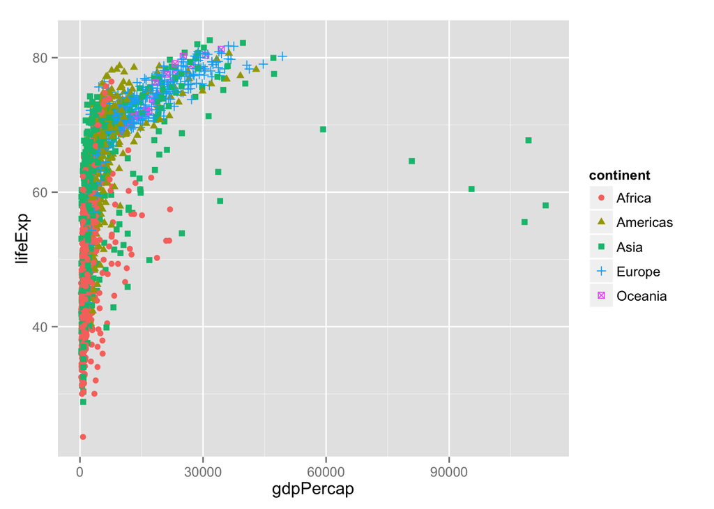

```r
ggplot(data = gapminder, aes(x = gdpPercap, y = lifeExp)) +
  geom_point(aes(color = continent, shape = continent))
```

For the next plot, I added another layer to change the x axis to a log10 scale.

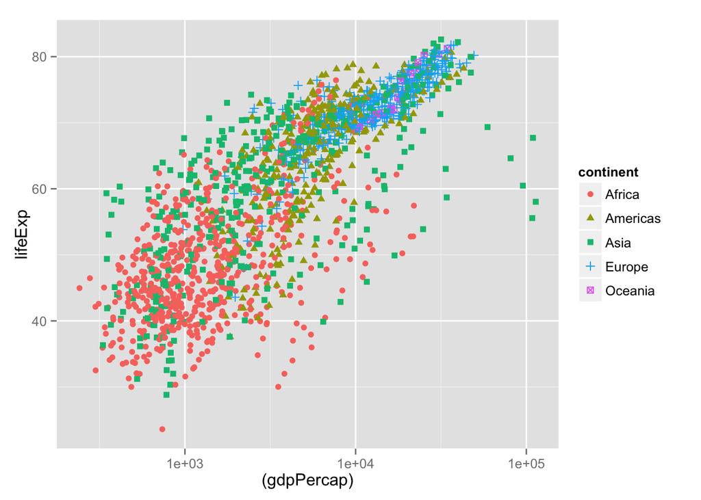

```r
ggplot(data = gapminder, aes(x = (gdpPercap), y = lifeExp)) +
  geom_point(aes(color = continent, shape = continent)) +
  scale_x_log10()
```

I then added a fourth layer that plotted a line using a linear fit (lm).

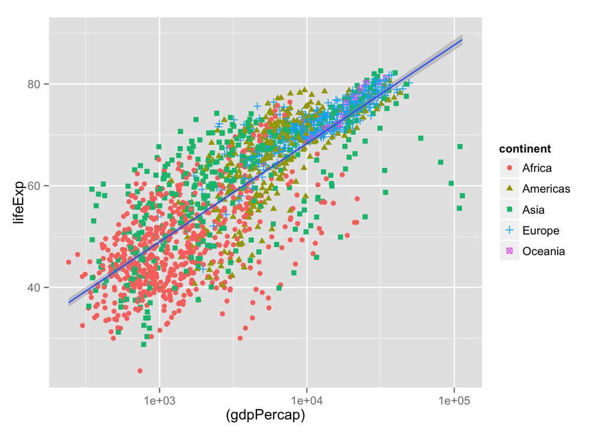

```r
ggplot(data = gapminder, aes(x = (gdpPercap), y = lifeExp)) +
  geom_point(aes(color = continent, shape = continent)) +
  scale_x_log10() +
  geom_smooth(method = lm)
```

To clean it up a little, I changed the names of the axes in a fifth layer.

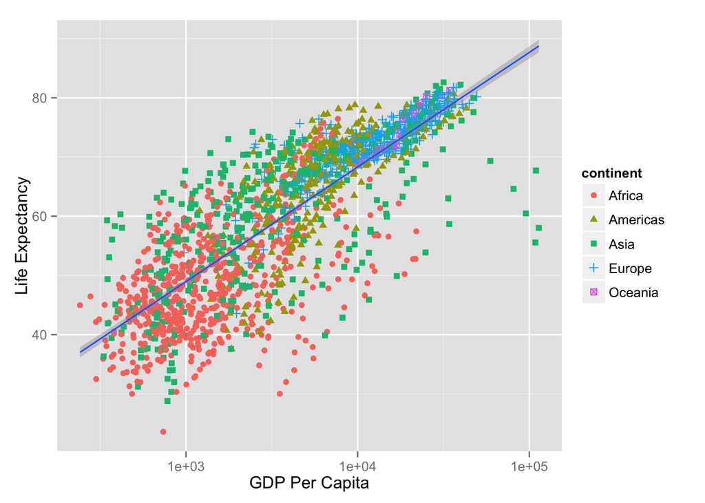

```r
ggplot(data = gapminder, aes(x = (gdpPercap), y = lifeExp)) +
  geom_point(aes(color = continent, shape = continent)) +
  scale_x_log10() +
  geom_smooth(method = lm) +
  labs(x = "GDP Per Capita", y = "Life Expectancy")
```

For the next plot, I started from scratch. I created a density plot lifeExp and faceted it by year. I changed the opacity of the fill using the alpha parameter. I also cleaned up the axes in the same way as above.

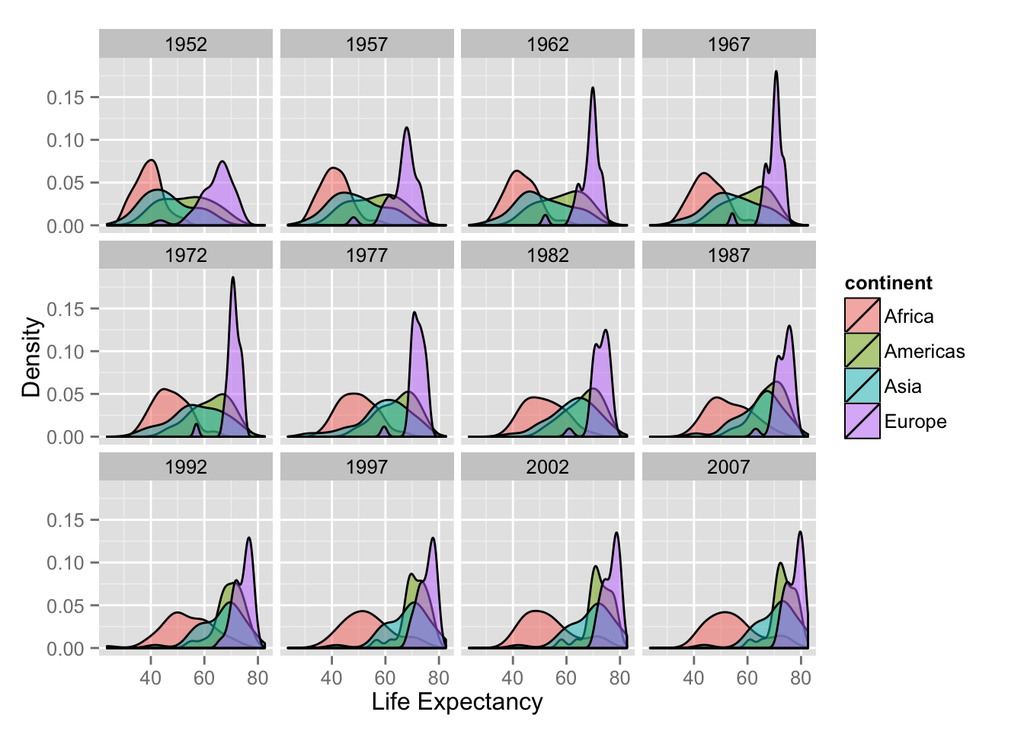

```r
ggplot(data = gapminder, aes(x = lifeExp, fill = continent)) +
  geom_density(alpha = 0.5) +
  facet_wrap(~ year)+
  labs(x = "Life Expectancy", y = "Density")
```

The next plot was made by creating a boxplot of lifeExp for each continent (with continents designated by color). I then faceted it by year.

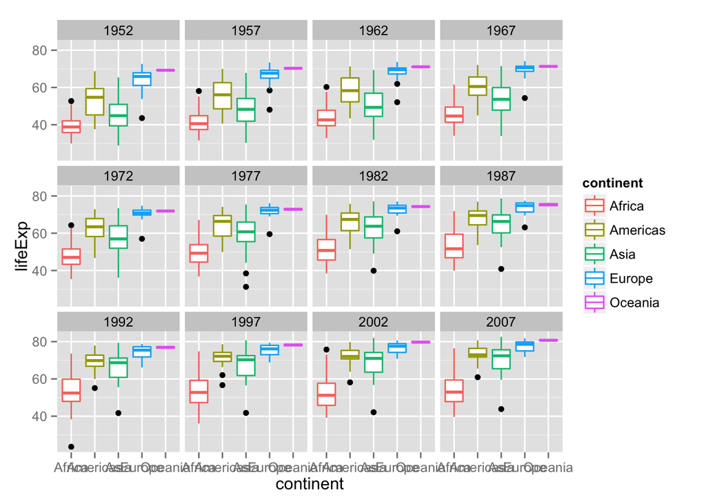

```r
ggplot(data = gapminder, aes(x = continent, y = lifeExp, color = continent)) +
  geom_boxplot() +
  facet_wrap(~ year)
```

To make the x axis more legible, I rotated the continent labels by 90 degrees and cleaned up the names again.

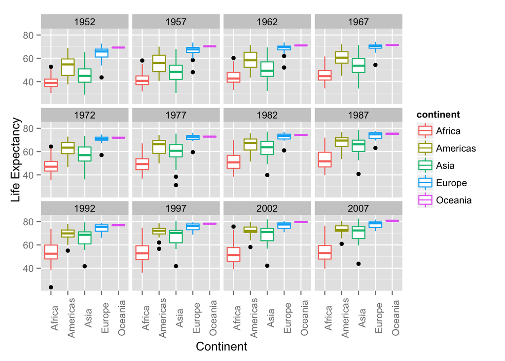

```r
ggplot(data = gapminder, aes(x = continent, y = lifeExp, color = continent)) +
  geom_boxplot() +
  facet_wrap(~ year) +
  theme(axis.text.x = element_text(angle = 90)) +
  labs(x = "Continent", y = "Life Expectancy")
```

#### Part II

This first plot of part II is the unfaceted version of the earlier lifeExp density plot.

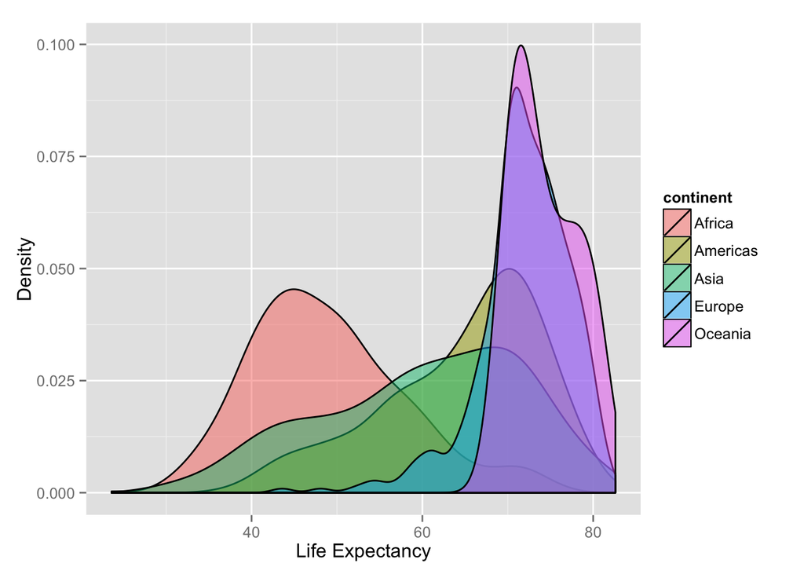

```r
ggplot(data = gapminder, aes(x = lifeExp, fill = continent)) +
  geom_density(alpha = 0.5) +
  labs(x = "Life Expectancy", y = "Density")
```

For the next plots, I needed to use dplyr so I loaded it from my library.

```r
library(dplyr)
```

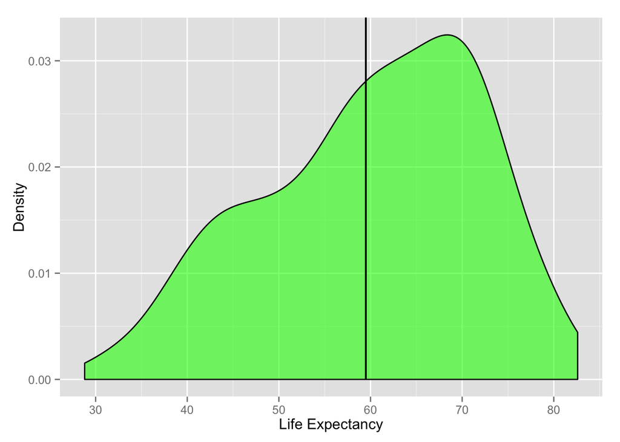

```r
asia_mean <- mean(gapminder$lifeExp, continent = "Asia")

subset(gapminder, continent == "Asia") %>%
  ggplot(aes(x = lifeExp, fill = continent)) +
  geom_density(alpha = 0.6, fill = "green1") +
  geom_linerange(x = asia_mean, ymin = 0, ymax = 0.04) +
  labs(x = "Life Expectancy", y = "Density")
```

To create my data.frame for this plot (which I designated “continent_mean”), I grouped my continent and then summarized the mean lifeExp. I created a lifeExp density plot that was faceted by continent. I used vline and my continent mean data.frame to created vertical mean lines for my plots.

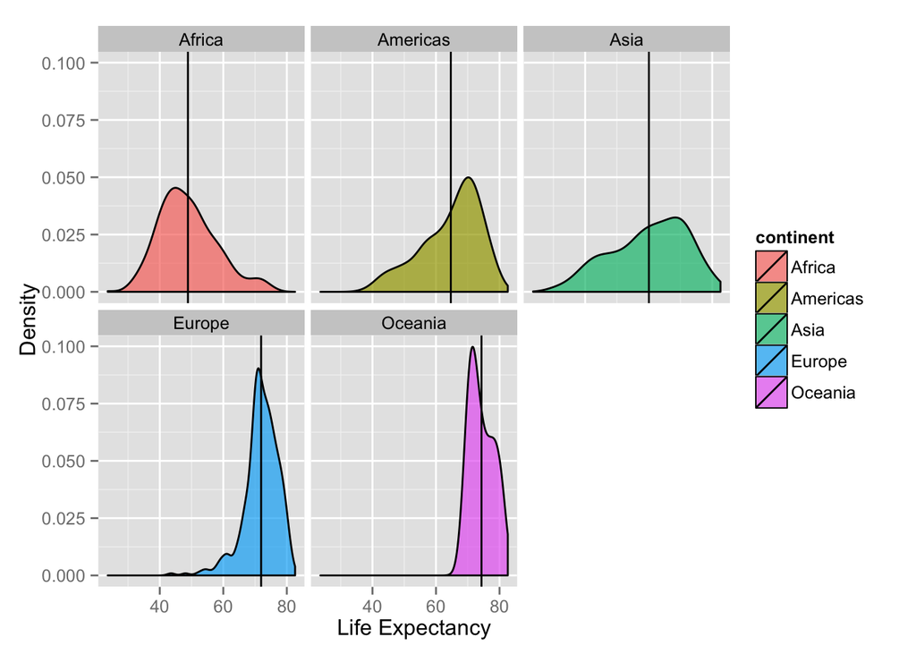

```r
continent_mean <- group_by(gapminder, continent) %>%
  summarize(mean_life = mean(lifeExp))

ggplot(gapminder, aes(x = lifeExp, fill = continent)) +
  geom_density(alpha = 0.7) +
  geom_vline(aes(xintercept = continent_mean$mean_life), continent_mean) +
  facet_wrap(~ continent) +
  labs(x = "Life Expectancy", y = "Density")
```

For fun, I added a scale fill with a “Blues”" palette.

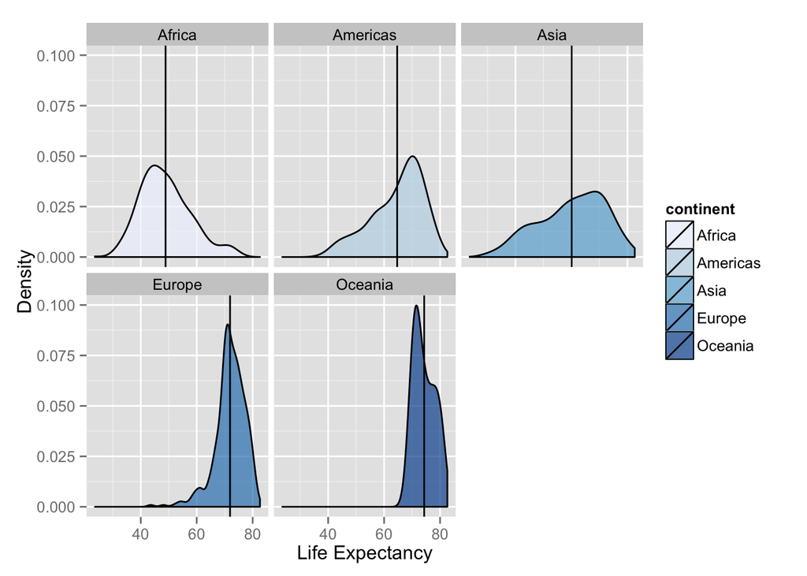

```r
ggplot(gapminder, aes(x = lifeExp, fill = continent)) +
  geom_density(alpha = 0.7) +
  scale_fill_brewer(palette = "Blues") +
  geom_vline(aes(xintercept = continent_mean$mean_life), continent_mean) +
  facet_wrap(~ continent) +
  labs(x = "Life Expectancy", y = "Density")
```

#### Part III

First, I had to find out my working directory and make sure the dataset was there.

```r
getwd()
```

```
## [1] "/Users/caseymccabe/Desktop/R Class/R Projects/Homework/R Class"
```

```r
library(ggplot2)
```

To fit the second line, I added “file =” before the file name.

```r
hw_gapminder <- read.csv(file = './hw_gapminder.csv')
```

In the third line I deleted the e in “lifeExpe” to fix the spelling error.

```r
mean_lifeExp <- mean(hw_gapminder$lifeExp)
mean_lifeExp
```

```
## [1] 59.47444
```

I changed expression to select columns and slice out appropriate rows (there is probably an easier way).

```r
small_set <- select(hw_gapminder, one_of('country', 'continent', 'year')) %>%
  slice(c(1, 2, 3, 4, 1300:1304))
small_set
```

```
##                 country continent year
## 1           Afghanistan      Asia 1952
## 2           Afghanistan      Asia 1957
## 3           Afghanistan      Asia 1962
## 4           Afghanistan      Asia 1967
## 5 Sao Tome and Principe    Africa 1967
## 6 Sao Tome and Principe    Africa 1972
## 7 Sao Tome and Principe    Africa 1977
## 8 Sao Tome and Principe    Africa 1982
## 9 Sao Tome and Principe    Africa 1987
```

I used ?mean and found out that if NA_real_ is returned then x is not logical. To fix that I changed na.rm to TRUE.

```r
mean_gdp <- mean(hw_gapminder$gdpPercap, na.rm = TRUE)
mean_gdp
```

```
## [1] 7210.019
```

I don’t really understand how to fix the which function so I used filter instead and had it tell me the country name.

```r
max_country <- filter(hw_gapminder, lifeExp == max(lifeExp))["country"]
max_country
```

```
##   country
## 1   Japan
```